# Risk Factor Analysis

## Outcome Variable

**Outcome Variable:** sstunted

## Predictor Variables

**Intervention Variable:** gagebrth

**Adjustment Set:**

unadjusted

## Stratifying Variables

The analysis was stratified on these variable(s):

- agecat
- studyid
- country

## Data Summary

| agecat | studyid | country | gagebrth | sstunted | n_cell | n |
| --- | --- | --- | --- | --- | --- | --- |
| Birth | ki1000108-CMC-V-BCS-2002 | INDIA | Full or late term | 0 | 54 | 90 |
| Birth | ki1000108-CMC-V-BCS-2002 | INDIA | Full or late term | 1 | 3 | 90 |
| Birth | ki1000108-CMC-V-BCS-2002 | INDIA | Preterm | 0 | 10 | 90 |
| Birth | ki1000108-CMC-V-BCS-2002 | INDIA | Preterm | 1 | 0 | 90 |
| Birth | ki1000108-CMC-V-BCS-2002 | INDIA | Early term | 0 | 23 | 90 |
| Birth | ki1000108-CMC-V-BCS-2002 | INDIA | Early term | 1 | 0 | 90 |
| Birth | ki1000108-IRC | INDIA | Full or late term | 0 | 228 | 369 |
| Birth | ki1000108-IRC | INDIA | Full or late term | 1 | 10 | 369 |
| Birth | ki1000108-IRC | INDIA | Preterm | 0 | 33 | 369 |
| Birth | ki1000108-IRC | INDIA | Preterm | 1 | 3 | 369 |
| Birth | ki1000108-IRC | INDIA | Early term | 0 | 93 | 369 |
| Birth | ki1000108-IRC | INDIA | Early term | 1 | 2 | 369 |
| Birth | ki1000109-EE | PAKISTAN | Full or late term | 0 | 0 | 4 |
| Birth | ki1000109-EE | PAKISTAN | Full or late term | 1 | 0 | 4 |
| Birth | ki1000109-EE | PAKISTAN | Preterm | 0 | 2 | 4 |
| Birth | ki1000109-EE | PAKISTAN | Preterm | 1 | 0 | 4 |
| Birth | ki1000109-EE | PAKISTAN | Early term | 0 | 2 | 4 |
| Birth | ki1000109-EE | PAKISTAN | Early term | 1 | 0 | 4 |
| Birth | ki1000304b-SAS-CompFeed | INDIA | Full or late term | 0 | 1 | 187 |
| Birth | ki1000304b-SAS-CompFeed | INDIA | Full or late term | 1 | 0 | 187 |
| Birth | ki1000304b-SAS-CompFeed | INDIA | Preterm | 0 | 161 | 187 |
| Birth | ki1000304b-SAS-CompFeed | INDIA | Preterm | 1 | 10 | 187 |
| Birth | ki1000304b-SAS-CompFeed | INDIA | Early term | 0 | 14 | 187 |
| Birth | ki1000304b-SAS-CompFeed | INDIA | Early term | 1 | 1 | 187 |
| Birth | ki1017093c-NIH-Crypto | BANGLADESH | Full or late term | 0 | 7 | 27 |
| Birth | ki1017093c-NIH-Crypto | BANGLADESH | Full or late term | 1 | 0 | 27 |
| Birth | ki1017093c-NIH-Crypto | BANGLADESH | Preterm | 0 | 5 | 27 |
| Birth | ki1017093c-NIH-Crypto | BANGLADESH | Preterm | 1 | 0 | 27 |
| Birth | ki1017093c-NIH-Crypto | BANGLADESH | Early term | 0 | 14 | 27 |
| Birth | ki1017093c-NIH-Crypto | BANGLADESH | Early term | 1 | 1 | 27 |

[output cut: 168 more lines]

The following strata were considered:

- agecat: 24 months, studyid: ki1000108-CMC-V-BCS-2002, country: INDIA
- agecat: 24 months, studyid: ki1000108-IRC, country: INDIA
- agecat: 24 months, studyid: ki1017093c-NIH-Crypto, country: BANGLADESH
- agecat: 24 months, studyid: ki1066203-TanzaniaChild2, country: TANZANIA, UNITED REPUBLIC OF
- agecat: 24 months, studyid: ki1101329-Keneba, country: GAMBIA
- agecat: 24 months, studyid: ki1119695-PROBIT, country: BELARUS
- agecat: 24 months, studyid: ki1135781-COHORTS, country: GUATEMALA
- agecat: 24 months, studyid: ki1135781-COHORTS, country: INDIA
- agecat: 24 months, studyid: ki1135781-COHORTS, country: PHILIPPINES
- agecat: 24 months, studyid: kiGH5241-JiVitA-3, country: BANGLADESH
- agecat: 6 months, studyid: ki1000108-CMC-V-BCS-2002, country: INDIA
- agecat: 6 months, studyid: ki1000108-IRC, country: INDIA
- agecat: 6 months, studyid: ki1000109-EE, country: PAKISTAN
- agecat: 6 months, studyid: ki1000304b-SAS-CompFeed, country: INDIA
- agecat: 6 months, studyid: ki1017093c-NIH-Crypto, country: BANGLADESH
- agecat: 6 months, studyid: ki1066203-TanzaniaChild2, country: TANZANIA, UNITED REPUBLIC OF
- agecat: 6 months, studyid: ki1101329-Keneba, country: GAMBIA
- agecat: 6 months, studyid: ki1119695-PROBIT, country: BELARUS
- agecat: 6 months, studyid: ki1135781-COHORTS, country: GUATEMALA
- agecat: 6 months, studyid: ki1135781-COHORTS, country: INDIA
- agecat: 6 months, studyid: ki1135781-COHORTS, country: PHILIPPINES
- agecat: 6 months, studyid: kiGH5241-JiVitA-3, country: BANGLADESH
- agecat: Birth, studyid: ki1000108-CMC-V-BCS-2002, country: INDIA
- agecat: Birth, studyid: ki1000108-IRC, country: INDIA
- agecat: Birth, studyid: ki1000109-EE, country: PAKISTAN
- agecat: Birth, studyid: ki1000304b-SAS-CompFeed, country: INDIA
- agecat: Birth, studyid: ki1017093c-NIH-Crypto, country: BANGLADESH
- agecat: Birth, studyid: ki1101329-Keneba, country: GAMBIA
- agecat: Birth, studyid: ki1119695-PROBIT, country: BELARUS
- agecat: Birth, studyid: ki1135781-COHORTS, country: GUATEMALA
- agecat: Birth, studyid: ki1135781-COHORTS, country: INDIA
- agecat: Birth, studyid: ki1135781-COHORTS, country: PHILIPPINES
- agecat: Birth, studyid: kiGH5241-JiVitA-3, country: BANGLADESH

### Dropped Strata

Some strata were dropped due to rare outcomes:

- agecat: Birth, studyid: ki1000108-CMC-V-BCS-2002, country: INDIA
- agecat: Birth, studyid: ki1000108-IRC, country: INDIA
- agecat: Birth, studyid: ki1000109-EE, country: PAKISTAN
- agecat: Birth, studyid: ki1000304b-SAS-CompFeed, country: INDIA
- agecat: Birth, studyid: ki1017093c-NIH-Crypto, country: BANGLADESH
- agecat: Birth, studyid: ki1119695-PROBIT, country: BELARUS
- agecat: Birth, studyid: ki1135781-COHORTS, country: GUATEMALA
- agecat: Birth, studyid: ki1135781-COHORTS, country: PHILIPPINES
- agecat: 6 months, studyid: ki1000108-IRC, country: INDIA
- agecat: 6 months, studyid: ki1000304b-SAS-CompFeed, country: INDIA
- agecat: 6 months, studyid: ki1017093c-NIH-Crypto, country: BANGLADESH
- agecat: 6 months, studyid: ki1066203-TanzaniaChild2, country: TANZANIA, UNITED REPUBLIC OF
- agecat: 6 months, studyid: ki1101329-Keneba, country: GAMBIA
- agecat: 24 months, studyid: ki1017093c-NIH-Crypto, country: BANGLADESH
- agecat: 24 months, studyid: ki1066203-TanzaniaChild2, country: TANZANIA, UNITED REPUBLIC OF

## Methods Detail

We’re interested in the causal parameters $E[Y_a]$ for all values of $a \in \mathcal{A}$. These parameters represent the mean outcome if, possibly contrary to fact, we intervened to set all units to have $A=a$. Under the randomization and positivity assumptions, these are identified by the statistical parameters $\psi_a=E_W[E_{Y|A,W}(Y|A=a,W)]$. In addition, we’re interested in the mean of $Y$, $E[Y]$ under no intervention (the observed mean). We will estimate these parameters by using SuperLearner to fit the relevant likelihood factors – $E_{Y|A,W}(Y|A=a,W)$ and $p(A=a|W)$, and then updating our likelihood fit using a joint TMLE.

For unadjusted analyses ($W=\{\}$), initial likelihoods were estimated using Lrnr_glm to estimate the simple $E(Y|A)$ and Lrnr_mean to estimate $p(A)$. For adjusted analyses, a small library containing Lrnr_glmnet, Lrnr_xgboost, and Lrnr_mean was used.

Having estimated these parameters, we will then use the delta method to estimate relative risks and attributable risks relative to a prespecified baseline level of $A$.

# Results Detail

## Results Plots

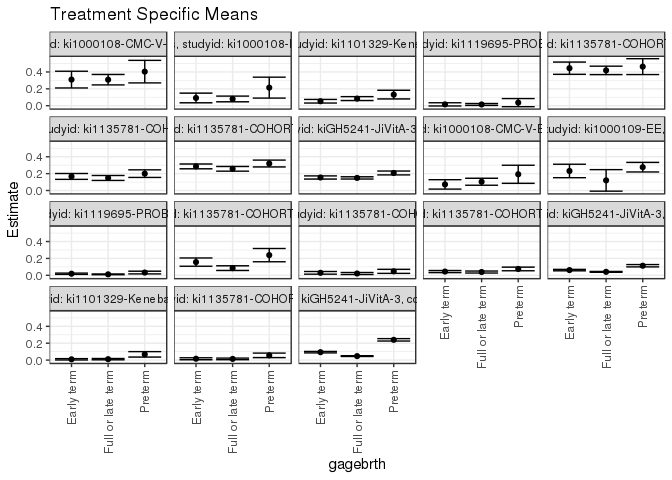

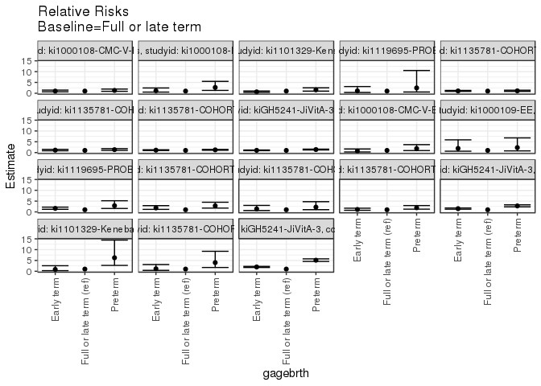

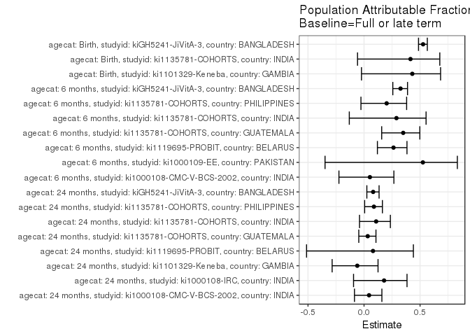

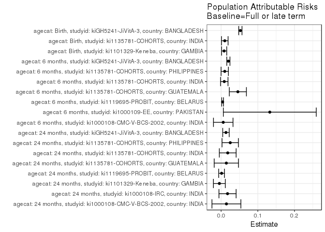

## Results Table

### Parameter: TSM

| agecat | studyid | country | intervention_level | baseline_level | estimate | ci_lower | ci_upper |
| --- | --- | --- | --- | --- | --- | --- | --- |
| Birth | ki1101329-Keneba | GAMBIA | Full or late term | NA | 0.0108992 | 0.0033854 | 0.0184130 |
| Birth | ki1101329-Keneba | GAMBIA | Preterm | NA | 0.0680851 | 0.0358691 | 0.1003011 |
| Birth | ki1101329-Keneba | GAMBIA | Early term | NA | 0.0091575 | 0.0011649 | 0.0171501 |
| Birth | ki1135781-COHORTS | INDIA | Full or late term | NA | 0.0140351 | 0.0043742 | 0.0236960 |
| Birth | ki1135781-COHORTS | INDIA | Preterm | NA | 0.0561404 | 0.0294051 | 0.0828756 |
| Birth | ki1135781-COHORTS | INDIA | Early term | NA | 0.0159817 | 0.0042330 | 0.0277305 |
| Birth | kiGH5241-JiVitA-3 | BANGLADESH | Full or late term | NA | 0.0470551 | 0.0425221 | 0.0515882 |
| Birth | kiGH5241-JiVitA-3 | BANGLADESH | Preterm | NA | 0.2400636 | 0.2257825 | 0.2543447 |
| Birth | kiGH5241-JiVitA-3 | BANGLADESH | Early term | NA | 0.0935912 | 0.0848687 | 0.1023138 |
| 6 months | ki1000108-CMC-V-BCS-2002 | INDIA | Full or late term | NA | 0.1037736 | 0.0626625 | 0.1448847 |
| 6 months | ki1000108-CMC-V-BCS-2002 | INDIA | Preterm | NA | 0.1923077 | 0.0850337 | 0.2995817 |
| 6 months | ki1000108-CMC-V-BCS-2002 | INDIA | Early term | NA | 0.0722892 | 0.0164963 | 0.1280820 |
| 6 months | ki1000109-EE | PAKISTAN | Full or late term | NA | 0.1200000 | -0.0075541 | 0.2475541 |
| 6 months | ki1000109-EE | PAKISTAN | Preterm | NA | 0.2761506 | 0.2193921 | 0.3329091 |
| 6 months | ki1000109-EE | PAKISTAN | Early term | NA | 0.2314815 | 0.1518278 | 0.3111352 |
| 6 months | ki1119695-PROBIT | BELARUS | Full or late term | NA | 0.0113636 | 0.0068846 | 0.0158427 |
| 6 months | ki1119695-PROBIT | BELARUS | Preterm | NA | 0.0326679 | 0.0167924 | 0.0485433 |
| 6 months | ki1119695-PROBIT | BELARUS | Early term | NA | 0.0186059 | 0.0111432 | 0.0260687 |
| 6 months | ki1135781-COHORTS | GUATEMALA | Full or late term | NA | 0.0848329 | 0.0571246 | 0.1125412 |
| 6 months | ki1135781-COHORTS | GUATEMALA | Preterm | NA | 0.2389381 | 0.1602577 | 0.3176184 |
| 6 months | ki1135781-COHORTS | GUATEMALA | Early term | NA | 0.1563981 | 0.1073529 | 0.2054433 |
| 6 months | ki1135781-COHORTS | INDIA | Full or late term | NA | 0.0211268 | 0.0092958 | 0.0329577 |
| 6 months | ki1135781-COHORTS | INDIA | Preterm | NA | 0.0468227 | 0.0228679 | 0.0707776 |
| 6 months | ki1135781-COHORTS | INDIA | Early term | NA | 0.0292135 | 0.0135609 | 0.0448661 |
| 6 months | ki1135781-COHORTS | PHILIPPINES | Full or late term | NA | 0.0389105 | 0.0270870 | 0.0507341 |
| 6 months | ki1135781-COHORTS | PHILIPPINES | Preterm | NA | 0.0750436 | 0.0534677 | 0.0966195 |
| 6 months | ki1135781-COHORTS | PHILIPPINES | Early term | NA | 0.0441989 | 0.0319724 | 0.0564254 |
| 6 months | kiGH5241-JiVitA-3 | BANGLADESH | Full or late term | NA | 0.0408472 | 0.0359454 | 0.0457490 |
| 6 months | kiGH5241-JiVitA-3 | BANGLADESH | Preterm | NA | 0.1133333 | 0.0995315 | 0.1271352 |
| 6 months | kiGH5241-JiVitA-3 | BANGLADESH | Early term | NA | 0.0616537 | 0.0531487 | 0.0701587 |
| 24 months | ki1000108-CMC-V-BCS-2002 | INDIA | Full or late term | NA | 0.3084112 | 0.2464455 | 0.3703769 |
| 24 months | ki1000108-CMC-V-BCS-2002 | INDIA | Preterm | NA | 0.4038462 | 0.2702928 | 0.5373995 |
| 24 months | ki1000108-CMC-V-BCS-2002 | INDIA | Early term | NA | 0.3095238 | 0.2105202 | 0.4085274 |
| 24 months | ki1000108-IRC | INDIA | Full or late term | NA | 0.0800000 | 0.0463276 | 0.1136724 |
| 24 months | ki1000108-IRC | INDIA | Preterm | NA | 0.2142857 | 0.0900319 | 0.3385396 |
| 24 months | ki1000108-IRC | INDIA | Early term | NA | 0.0918367 | 0.0345858 | 0.1490877 |
| 24 months | ki1101329-Keneba | GAMBIA | Full or late term | NA | 0.0843806 | 0.0612872 | 0.1074740 |
| 24 months | ki1101329-Keneba | GAMBIA | Preterm | NA | 0.1317365 | 0.0804201 | 0.1830530 |
| 24 months | ki1101329-Keneba | GAMBIA | Early term | NA | 0.0532407 | 0.0320603 | 0.0744212 |
| 24 months | ki1119695-PROBIT | BELARUS | Full or late term | NA | 0.0148221 | 0.0038188 | 0.0258255 |
| 24 months | ki1119695-PROBIT | BELARUS | Preterm | NA | 0.0364964 | -0.0116126 | 0.0846053 |
| 24 months | ki1119695-PROBIT | BELARUS | Early term | NA | 0.0160085 | -0.0030877 | 0.0351047 |
| 24 months | ki1135781-COHORTS | GUATEMALA | Full or late term | NA | 0.4186667 | 0.3686969 | 0.4686364 |
| 24 months | ki1135781-COHORTS | GUATEMALA | Preterm | NA | 0.4629630 | 0.3688522 | 0.5570737 |
| 24 months | ki1135781-COHORTS | GUATEMALA | Early term | NA | 0.4444444 | 0.3717984 | 0.5170905 |
| 24 months | ki1135781-COHORTS | INDIA | Full or late term | NA | 0.1486726 | 0.1193262 | 0.1780189 |
| 24 months | ki1135781-COHORTS | INDIA | Preterm | NA | 0.2000000 | 0.1550919 | 0.2449081 |
| 24 months | ki1135781-COHORTS | INDIA | Early term | NA | 0.1666667 | 0.1317518 | 0.2015816 |
| 24 months | ki1135781-COHORTS | PHILIPPINES | Full or late term | NA | 0.2569296 | 0.2289618 | 0.2848974 |
| 24 months | ki1135781-COHORTS | PHILIPPINES | Preterm | NA | 0.3196881 | 0.2793239 | 0.3600523 |
| 24 months | ki1135781-COHORTS | PHILIPPINES | Early term | NA | 0.2857143 | 0.2573231 | 0.3141055 |
| 24 months | kiGH5241-JiVitA-3 | BANGLADESH | Full or late term | NA | 0.1490957 | 0.1356809 | 0.1625106 |
| 24 months | kiGH5241-JiVitA-3 | BANGLADESH | Preterm | NA | 0.2080278 | 0.1850836 | 0.2309720 |
| 24 months | kiGH5241-JiVitA-3 | BANGLADESH | Early term | NA | 0.1542746 | 0.1354377 | 0.1731114 |

### Parameter: E(Y)

| agecat | studyid | country | intervention_level | baseline_level | estimate | ci_lower | ci_upper |
| --- | --- | --- | --- | --- | --- | --- | --- |
| Birth | ki1101329-Keneba | GAMBIA | NA | NA | 0.0191419 | 0.0122398 | 0.0260440 |
| Birth | ki1135781-COHORTS | INDIA | NA | NA | 0.0239753 | 0.0156340 | 0.0323165 |
| Birth | kiGH5241-JiVitA-3 | BANGLADESH | NA | NA | 0.0994901 | 0.0949359 | 0.1040443 |
| 6 months | ki1000108-CMC-V-BCS-2002 | INDIA | NA | NA | 0.1095101 | 0.0766059 | 0.1424143 |
| 6 months | ki1000109-EE | PAKISTAN | NA | NA | 0.2526882 | 0.2084696 | 0.2969067 |
| 6 months | ki1119695-PROBIT | BELARUS | NA | NA | 0.0154178 | 0.0100323 | 0.0208033 |
| 6 months | ki1135781-COHORTS | GUATEMALA | NA | NA | 0.1304348 | 0.1056973 | 0.1551723 |
| 6 months | ki1135781-COHORTS | INDIA | NA | NA | 0.0297256 | 0.0205326 | 0.0389187 |
| 6 months | ki1135781-COHORTS | PHILIPPINES | NA | NA | 0.0487533 | 0.0406091 | 0.0568974 |
| 6 months | kiGH5241-JiVitA-3 | BANGLADESH | NA | NA | 0.0605721 | 0.0559673 | 0.0651769 |
| 24 months | ki1000108-CMC-V-BCS-2002 | INDIA | NA | NA | 0.3228571 | 0.2738024 | 0.3719119 |
| 24 months | ki1000108-IRC | INDIA | NA | NA | 0.0974359 | 0.0679665 | 0.1269053 |
| 24 months | ki1101329-Keneba | GAMBIA | NA | NA | 0.0795848 | 0.0639762 | 0.0951934 |
| 24 months | ki1119695-PROBIT | BELARUS | NA | NA | 0.0161090 | 0.0034156 | 0.0288025 |
| 24 months | ki1135781-COHORTS | GUATEMALA | NA | NA | 0.4328808 | 0.3951375 | 0.4706242 |
| 24 months | ki1135781-COHORTS | INDIA | NA | NA | 0.1666667 | 0.1464624 | 0.1868710 |
| 24 months | ki1135781-COHORTS | PHILIPPINES | NA | NA | 0.2817657 | 0.2638535 | 0.2996779 |
| 24 months | kiGH5241-JiVitA-3 | BANGLADESH | NA | NA | 0.1622891 | 0.1518212 | 0.1727571 |

### Parameter: RR

| agecat | studyid | country | intervention_level | baseline_level | estimate | ci_lower | ci_upper |
| --- | --- | --- | --- | --- | --- | --- | --- |
| Birth | ki1101329-Keneba | GAMBIA | Full or late term | Full or late term | 1.0000000 | 1.0000000 | 1.000000 |
| Birth | ki1101329-Keneba | GAMBIA | Preterm | Full or late term | 6.2468085 | 2.7072028 | 14.414368 |
| Birth | ki1101329-Keneba | GAMBIA | Early term | Full or late term | 0.8402015 | 0.2762834 | 2.555125 |
| Birth | ki1135781-COHORTS | INDIA | Full or late term | Full or late term | 1.0000000 | 1.0000000 | 1.000000 |
| Birth | ki1135781-COHORTS | INDIA | Preterm | Full or late term | 4.0000000 | 1.7320013 | 9.237869 |
| Birth | ki1135781-COHORTS | INDIA | Early term | Full or late term | 1.1386986 | 0.4159430 | 3.117338 |
| Birth | kiGH5241-JiVitA-3 | BANGLADESH | Full or late term | Full or late term | 1.0000000 | 1.0000000 | 1.000000 |
| Birth | kiGH5241-JiVitA-3 | BANGLADESH | Preterm | Full or late term | 5.1017523 | 4.5408945 | 5.731883 |
| Birth | kiGH5241-JiVitA-3 | BANGLADESH | Early term | Full or late term | 1.9889703 | 1.7430131 | 2.269635 |
| 6 months | ki1000108-CMC-V-BCS-2002 | INDIA | Full or late term | Full or late term | 1.0000000 | 1.0000000 | 1.000000 |
| 6 months | ki1000108-CMC-V-BCS-2002 | INDIA | Preterm | Full or late term | 1.8531469 | 0.9349126 | 3.673234 |
| 6 months | ki1000108-CMC-V-BCS-2002 | INDIA | Early term | Full or late term | 0.6966046 | 0.2925632 | 1.658643 |
| 6 months | ki1000109-EE | PAKISTAN | Full or late term | Full or late term | 1.0000000 | 1.0000000 | 1.000000 |
| 6 months | ki1000109-EE | PAKISTAN | Preterm | Full or late term | 2.3012552 | 0.7794355 | 6.794373 |
| 6 months | ki1000109-EE | PAKISTAN | Early term | Full or late term | 1.9290123 | 0.6311239 | 5.895972 |
| 6 months | ki1119695-PROBIT | BELARUS | Full or late term | Full or late term | 1.0000000 | 1.0000000 | 1.000000 |
| 6 months | ki1119695-PROBIT | BELARUS | Preterm | Full or late term | 2.8747731 | 1.6001362 | 5.164761 |
| 6 months | ki1119695-PROBIT | BELARUS | Early term | Full or late term | 1.6373230 | 1.2113497 | 2.213090 |
| 6 months | ki1135781-COHORTS | GUATEMALA | Full or late term | Full or late term | 1.0000000 | 1.0000000 | 1.000000 |
| 6 months | ki1135781-COHORTS | GUATEMALA | Preterm | Full or late term | 2.8165728 | 1.7713031 | 4.478670 |
| 6 months | ki1135781-COHORTS | GUATEMALA | Early term | Full or late term | 1.8436019 | 1.1722531 | 2.899432 |
| 6 months | ki1135781-COHORTS | INDIA | Full or late term | Full or late term | 1.0000000 | 1.0000000 | 1.000000 |
| 6 months | ki1135781-COHORTS | INDIA | Preterm | Full or late term | 2.2162765 | 1.0380224 | 4.731961 |
| 6 months | ki1135781-COHORTS | INDIA | Early term | Full or late term | 1.3827715 | 0.6370252 | 3.001541 |
| 6 months | ki1135781-COHORTS | PHILIPPINES | Full or late term | Full or late term | 1.0000000 | 1.0000000 | 1.000000 |
| 6 months | ki1135781-COHORTS | PHILIPPINES | Preterm | Full or late term | 1.9286213 | 1.2693171 | 2.930379 |
| 6 months | ki1135781-COHORTS | PHILIPPINES | Early term | Full or late term | 1.1359116 | 0.7531545 | 1.713188 |
| 6 months | kiGH5241-JiVitA-3 | BANGLADESH | Full or late term | Full or late term | 1.0000000 | 1.0000000 | 1.000000 |
| 6 months | kiGH5241-JiVitA-3 | BANGLADESH | Preterm | Full or late term | 2.7745679 | 2.3521239 | 3.272883 |
| 6 months | kiGH5241-JiVitA-3 | BANGLADESH | Early term | Full or late term | 1.5093740 | 1.2550832 | 1.815186 |
| 24 months | ki1000108-CMC-V-BCS-2002 | INDIA | Full or late term | Full or late term | 1.0000000 | 1.0000000 | 1.000000 |
| 24 months | ki1000108-CMC-V-BCS-2002 | INDIA | Preterm | Full or late term | 1.3094406 | 0.8892703 | 1.928136 |
| 24 months | ki1000108-CMC-V-BCS-2002 | INDIA | Early term | Full or late term | 1.0036075 | 0.6878903 | 1.464228 |
| 24 months | ki1000108-IRC | INDIA | Full or late term | Full or late term | 1.0000000 | 1.0000000 | 1.000000 |
| 24 months | ki1000108-IRC | INDIA | Preterm | Full or late term | 2.6785714 | 1.3083567 | 5.483783 |
| 24 months | ki1000108-IRC | INDIA | Early term | Full or late term | 1.1479592 | 0.5410719 | 2.435555 |
| 24 months | ki1101329-Keneba | GAMBIA | Full or late term | Full or late term | 1.0000000 | 1.0000000 | 1.000000 |
| 24 months | ki1101329-Keneba | GAMBIA | Preterm | Full or late term | 1.5612180 | 0.9698610 | 2.513145 |
| 24 months | ki1101329-Keneba | GAMBIA | Early term | Full or late term | 0.6309594 | 0.3893073 | 1.022611 |
| 24 months | ki1119695-PROBIT | BELARUS | Full or late term | Full or late term | 1.0000000 | 1.0000000 | 1.000000 |
| 24 months | ki1119695-PROBIT | BELARUS | Preterm | Full or late term | 2.4622871 | 0.5762612 | 10.521023 |
| 24 months | ki1119695-PROBIT | BELARUS | Early term | Full or late term | 1.0800427 | 0.3773256 | 3.091474 |
| 24 months | ki1135781-COHORTS | GUATEMALA | Full or late term | Full or late term | 1.0000000 | 1.0000000 | 1.000000 |
| 24 months | ki1135781-COHORTS | GUATEMALA | Preterm | Full or late term | 1.1058033 | 0.8735792 | 1.399760 |
| 24 months | ki1135781-COHORTS | GUATEMALA | Early term | Full or late term | 1.0615711 | 0.8670643 | 1.299711 |
| 24 months | ki1135781-COHORTS | INDIA | Full or late term | Full or late term | 1.0000000 | 1.0000000 | 1.000000 |
| 24 months | ki1135781-COHORTS | INDIA | Preterm | Full or late term | 1.3452381 | 0.9976078 | 1.814005 |
| 24 months | ki1135781-COHORTS | INDIA | Early term | Full or late term | 1.1210317 | 0.8406464 | 1.494936 |
| 24 months | ki1135781-COHORTS | PHILIPPINES | Full or late term | Full or late term | 1.0000000 | 1.0000000 | 1.000000 |
| 24 months | ki1135781-COHORTS | PHILIPPINES | Preterm | Full or late term | 1.2442633 | 1.0532041 | 1.469982 |
| 24 months | ki1135781-COHORTS | PHILIPPINES | Early term | Full or late term | 1.1120332 | 0.9596386 | 1.288629 |
| 24 months | kiGH5241-JiVitA-3 | BANGLADESH | Full or late term | Full or late term | 1.0000000 | 1.0000000 | 1.000000 |
| 24 months | kiGH5241-JiVitA-3 | BANGLADESH | Preterm | Full or late term | 1.3952633 | 1.2147228 | 1.602637 |
| 24 months | kiGH5241-JiVitA-3 | BANGLADESH | Early term | Full or late term | 1.0347351 | 0.8960514 | 1.194883 |

### Parameter: PAR

| agecat | studyid | country | intervention_level | baseline_level | estimate | ci_lower | ci_upper |
| --- | --- | --- | --- | --- | --- | --- | --- |
| Birth | ki1101329-Keneba | GAMBIA | Full or late term | NA | 0.0082427 | 0.0012149 | 0.0152706 |
| Birth | ki1135781-COHORTS | INDIA | Full or late term | NA | 0.0099402 | 0.0009613 | 0.0189190 |
| Birth | kiGH5241-JiVitA-3 | BANGLADESH | Full or late term | NA | 0.0524349 | 0.0479408 | 0.0569291 |
| 6 months | ki1000108-CMC-V-BCS-2002 | INDIA | Full or late term | NA | 0.0057365 | -0.0208651 | 0.0323381 |
| 6 months | ki1000109-EE | PAKISTAN | Full or late term | NA | 0.1326882 | 0.0060450 | 0.2593314 |
| 6 months | ki1119695-PROBIT | BELARUS | Full or late term | NA | 0.0040542 | 0.0016000 | 0.0065083 |
| 6 months | ki1135781-COHORTS | GUATEMALA | Full or late term | NA | 0.0456019 | 0.0223220 | 0.0688818 |
| 6 months | ki1135781-COHORTS | INDIA | Full or late term | NA | 0.0085988 | -0.0015643 | 0.0187620 |
| 6 months | ki1135781-COHORTS | PHILIPPINES | Full or late term | NA | 0.0098428 | -0.0001149 | 0.0198004 |
| 6 months | kiGH5241-JiVitA-3 | BANGLADESH | Full or late term | NA | 0.0197249 | 0.0154044 | 0.0240453 |
| 24 months | ki1000108-CMC-V-BCS-2002 | INDIA | Full or late term | NA | 0.0144459 | -0.0249323 | 0.0538242 |
| 24 months | ki1000108-IRC | INDIA | Full or late term | NA | 0.0174359 | -0.0059874 | 0.0408591 |
| 24 months | ki1101329-Keneba | GAMBIA | Full or late term | NA | -0.0047958 | -0.0210132 | 0.0114216 |
| 24 months | ki1119695-PROBIT | BELARUS | Full or late term | NA | 0.0012869 | -0.0065493 | 0.0091231 |
| 24 months | ki1135781-COHORTS | GUATEMALA | Full or late term | NA | 0.0142142 | -0.0189054 | 0.0473337 |
| 24 months | ki1135781-COHORTS | INDIA | Full or late term | NA | 0.0179941 | -0.0049278 | 0.0409160 |
| 24 months | ki1135781-COHORTS | PHILIPPINES | Full or late term | NA | 0.0248360 | 0.0025273 | 0.0471448 |
| 24 months | kiGH5241-JiVitA-3 | BANGLADESH | Full or late term | NA | 0.0131934 | 0.0043457 | 0.0220411 |

### Parameter: PAF

| agecat | studyid | country | intervention_level | baseline_level | estimate | ci_lower | ci_upper |
| --- | --- | --- | --- | --- | --- | --- | --- |
| Birth | ki1101329-Keneba | GAMBIA | Full or late term | NA | 0.4306117 | -0.0227788 | 0.6830174 |
| Birth | ki1135781-COHORTS | INDIA | Full or late term | NA | 0.4146010 | -0.0580236 | 0.6761018 |
| Birth | kiGH5241-JiVitA-3 | BANGLADESH | Full or late term | NA | 0.5270370 | 0.4861635 | 0.5646591 |
| 6 months | ki1000108-CMC-V-BCS-2002 | INDIA | Full or late term | NA | 0.0523833 | -0.2240006 | 0.2663587 |
| 6 months | ki1000109-EE | PAKISTAN | Full or late term | NA | 0.5251064 | -0.3479495 | 0.8326911 |
| 6 months | ki1119695-PROBIT | BELARUS | Full or late term | NA | 0.2629536 | 0.1193233 | 0.3831591 |
| 6 months | ki1135781-COHORTS | GUATEMALA | Full or late term | NA | 0.3496144 | 0.1575663 | 0.4978816 |
| 6 months | ki1135781-COHORTS | INDIA | Full or late term | NA | 0.2892741 | -0.1315262 | 0.5535841 |
| 6 months | ki1135781-COHORTS | PHILIPPINES | Full or late term | NA | 0.2018891 | -0.0275540 | 0.3800997 |
| 6 months | kiGH5241-JiVitA-3 | BANGLADESH | Full or late term | NA | 0.3256430 | 0.2568225 | 0.3880904 |
| 24 months | ki1000108-CMC-V-BCS-2002 | INDIA | Full or late term | NA | 0.0447440 | -0.0853337 | 0.1592319 |
| 24 months | ki1000108-IRC | INDIA | Full or late term | NA | 0.1789474 | -0.0935755 | 0.3835566 |
| 24 months | ki1101329-Keneba | GAMBIA | Full or late term | NA | -0.0602607 | -0.2845960 | 0.1248978 |
| 24 months | ki1119695-PROBIT | BELARUS | Full or late term | NA | 0.0798875 | -0.5128990 | 0.4404074 |
| 24 months | ki1135781-COHORTS | GUATEMALA | Full or late term | NA | 0.0328362 | -0.0468086 | 0.1064214 |
| 24 months | ki1135781-COHORTS | INDIA | Full or late term | NA | 0.1079646 | -0.0402673 | 0.2350743 |
| 24 months | ki1135781-COHORTS | PHILIPPINES | Full or late term | NA | 0.0881443 | 0.0054921 | 0.1639274 |
| 24 months | kiGH5241-JiVitA-3 | BANGLADESH | Full or late term | NA | 0.0812958 | 0.0250973 | 0.1342547 |